# Assignment A: Investigating the scope of the missingness problem

Martijn Koster

2/22/2022

# 1 Introduction

The matter of interest for this assignment will be the impact that incomplete data (**observed data**) has on our inferences compared to the inferences we make with complete data (**true data**). To investigate the effect that missing values have on model inferences, we will build a random multiple regression model.

Firstly, we provide descriptive statistics and correlations. In table 2.1 we compare the head of the observed data and the true data. Additionally in 2.2 the means and variances are compared. With regard to correlations, we present two correlations matrices. One for the observed data 2.3 and the other for the true data 2.4.

Secondly we present our multiple regression model in table 2.5. Our model consists of the outcome variable: *active heart rate* and the predictors: *age* and *smoke*. We also included an interaction effect between *bmi* and *sex*. The first three columns reflect the observed data whereas the following columns reflect the true data.

The research question we tend to answer in accordance with our model is: *What impact do missing values have on an “active heart rate” model inference?*

Thirldy we start by inspecting the missing values. We try to find out where the missings occur. In 3.1 we start by giving a global overview of the missings.

# 2 Observed vs True data

In this section we will compare the observed with the true dataset.

Table 2.1: Observed Data

| age | smoke | sex | intensity | active | rest | height | weight | bmi |
| --- | --- | --- | --- | --- | --- | --- | --- | --- |
| 42 | no | female | high | NA | 75 | NA | NA | 22.4 |
| 31 | NA | male | low | NA | 62 | NA | NA | 23.8 |
| 36 | no | male | low | 109 | 76 | 182 | 78.0 | 23.5 |
| 31 | no | female | low | 78 | 62 | 164 | 53.9 | 20.0 |
| 42 | no | male | low | NA | 66 | 189 | NA | 23.4 |

Table 2.1: True Data

| age | smoke | sex | intensity | active | rest | height | weight | bmi |
| --- | --- | --- | --- | --- | --- | --- | --- | --- |
| 42 | no | female | high | 94 | 75 | 161 | 58.1 | 22.4 |
| 31 | no | male | low | 86 | 62 | 184 | 80.6 | 23.8 |
| 36 | no | male | low | 109 | 76 | 182 | 78.0 | 23.5 |
| 31 | no | female | low | 78 | 62 | 164 | 53.9 | 20.0 |
| 42 | no | male | low | 103 | 66 | 189 | 83.6 | 23.4 |

## 2.1 Descriptives

Obviously, neither the mean nor the variance of age, and rest changed since these has no missing values.

The mean of height is is also almost entirely unaffected. The variance of active changed a bit in the observed data, but this difference is simply due to sampling variability (we’ve deleted about 30% of the observations). The missing values in active are MCAR, so we would not expect any substantial changes in the marginal distribution of height.

The mean of weight is is also almost entirely unaffected. The variance of active changed a bit in the observed data, but this difference is simply due to sampling variability (we’ve deleted about 57% of the observations). The missing values in active are MCAR, so we would not expect any substantial changes in the marginal distribution of weight.

The mean of bmi is is also almost entirely unaffected. The variance of active changed a bit in the observed data, but this difference is simply due to sampling variability (we’ve deleted about 30% of the observations). The missing values in active are MCAR, so we would not expect any substantial changes in the marginal distribution of bmi.

Table 2.2: Means and variances in true and observed dataset

| Variables | $M_{obs}$ | $M_{true}$ | var obs | var true |
| --- | --- | --- | --- | --- |
| Age | 38.52 | 38.52 | 149.73 | 149.73 |
| Active | 92.58 | 93.13 | 383.05 | 383.04 |
| Rest | 69.83 | 69.83 | 120.78 | 120.78 |
| Height | 174.50 | 173.99 | 100.66 | 105.29 |
| Weight | 73.91 | 73.58 | 260.26 | 274.85 |
| Bmi | 24.11 | 24.06 | 12.91 | 13.38 |

Note.  
obs = Observed Dataset, true = True Dataset

## 2.2 Correlations

Table 2.3: Correlations of observed data

|  | age | smoke | sex | intensity | active | rest | height | weight | bmi |
| --- | --- | --- | --- | --- | --- | --- | --- | --- | --- |
| age | 1.00 | 0.01 | -0.17 | 0.21 | -0.49 | -0.39 | 0.19 | 0.25 | 0.18 |
| smoke | 0.01 | 1.00 | -0.09 | -0.29 | 0.15 | 0.23 | 0.18 | 0.18 | 0.18 |
| sex | -0.17 | -0.09 | 1.00 | -0.09 | 0.11 | 0.06 | -0.73 | -0.68 | -0.42 |
| intensity | 0.21 | -0.29 | -0.09 | 1.00 | -0.37 | -0.55 | 0.13 | 0.12 | 0.02 |
| active | -0.49 | 0.15 | 0.11 | -0.37 | 1.00 | 0.56 | 0.00 | 0.01 | 0.05 |
| rest | -0.39 | 0.23 | 0.06 | -0.55 | 0.56 | 1.00 | -0.20 | -0.12 | 0.06 |
| height | 0.19 | 0.18 | -0.73 | 0.13 | 0.00 | -0.20 | 1.00 | 0.78 | 0.34 |
| weight | 0.25 | 0.18 | -0.68 | 0.12 | 0.01 | -0.12 | 0.78 | 1.00 | 0.88 |
| bmi | 0.18 | 0.18 | -0.42 | 0.02 | 0.05 | 0.06 | 0.34 | 0.88 | 1.00 |

Table 2.4: Correlations of true data

|  | age | smoke | sex | intensity | active | rest | height | weight | bmi |
| --- | --- | --- | --- | --- | --- | --- | --- | --- | --- |
| age | 1.00 | -0.05 | -0.17 | 0.21 | -0.54 | -0.39 | 0.20 | 0.23 | 0.20 |
| smoke | -0.05 | 1.00 | -0.11 | -0.31 | 0.18 | 0.27 | 0.17 | 0.25 | 0.24 |
| sex | -0.17 | -0.11 | 1.00 | -0.09 | 0.09 | 0.06 | -0.72 | -0.69 | -0.47 |
| intensity | 0.21 | -0.31 | -0.09 | 1.00 | -0.37 | -0.55 | 0.12 | 0.06 | 0.01 |
| active | -0.54 | 0.18 | 0.09 | -0.37 | 1.00 | 0.61 | -0.10 | 0.02 | 0.09 |
| rest | -0.39 | 0.27 | 0.06 | -0.55 | 0.61 | 1.00 | -0.15 | -0.04 | 0.05 |
| height | 0.20 | 0.17 | -0.72 | 0.12 | -0.10 | -0.15 | 1.00 | 0.77 | 0.36 |
| weight | 0.23 | 0.25 | -0.69 | 0.06 | 0.02 | -0.04 | 0.77 | 1.00 | 0.87 |
| bmi | 0.20 | 0.24 | -0.47 | 0.01 | 0.09 | 0.05 | 0.36 | 0.87 | 1.00 |

## 2.3 Regression

Table 2.5: Regression analysis of True and Observed Data

|  | $\beta_{obs}$ | $SE_{obs}$ | $p_{obs}$ | $\beta_{true}$ | $SE_{true}$ | $p_{true}$ |
| --- | --- | --- | --- | --- | --- | --- |
| (Intercept) | 78.444 | 14.34 | 0.000 | 80.384 | 9.03 | 0.000 |
| age | -0.809 | 0.11 | 0.000 | -0.883 | 0.07 | 0.000 |
| bmi | 1.681 | 0.55 | 0.003 | 1.776 | 0.35 | 0.000 |
| sexfemale | 32.756 | 20.78 | 0.117 | 43.460 | 14.16 | 0.002 |
| smokeyes | 1.615 | 2.91 | 0.580 | 3.516 | 1.99 | 0.078 |
| bmi:sexfemale | -1.131 | 0.88 | 0.199 | -1.674 | 0.60 | 0.006 |

## 2.4 Answering the research question

When examining Table 2.5 *Regression analysis of True and Observed data* we observe several differences in the beta coefficients, standard error and p-values. Regarding the beta coefficients, missing data caused the beta’s of the true data to be systematically underestimated. However, the standard error is systematically overestimated. Furthermore, the missing data caused several predictors to be wrongly non significant (type II error) in the observed data. This goes for *sexfemale* and the *bmi:sexfemale* interaction. Concluding, the missing data causes the standard errors to be greater, resulting in less accurate beta coefficients. Moreover, some p-values turn out non signifianct, caused by underestimated beta coefficients. Thus, the model based on observed data leads to inaccurate inferences.

# 3 Missingness

There are 540 missing values. 0 for age, 0 for sex, 0 for intensity, 0 for rest, 58 for smoke, 92 for height, 93 for bmi, 123 for active, and 174 for weight. moreover there are 132 completely observed rows, 15 rows with one missing value, 37 rows with two missing values, 52 rows with three missing values, 55 rows with four missing values, 15 rows with five missing values.

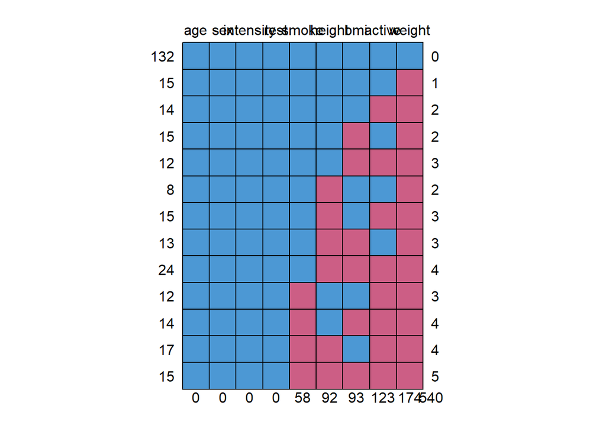

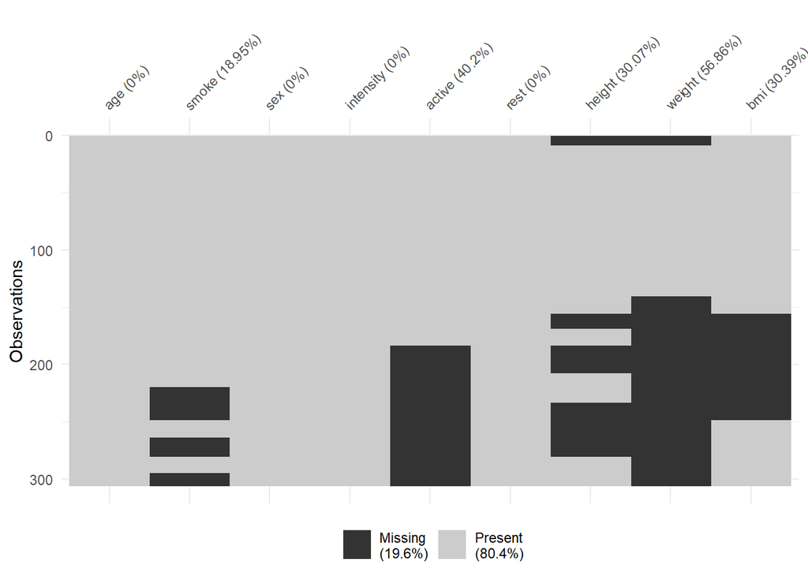

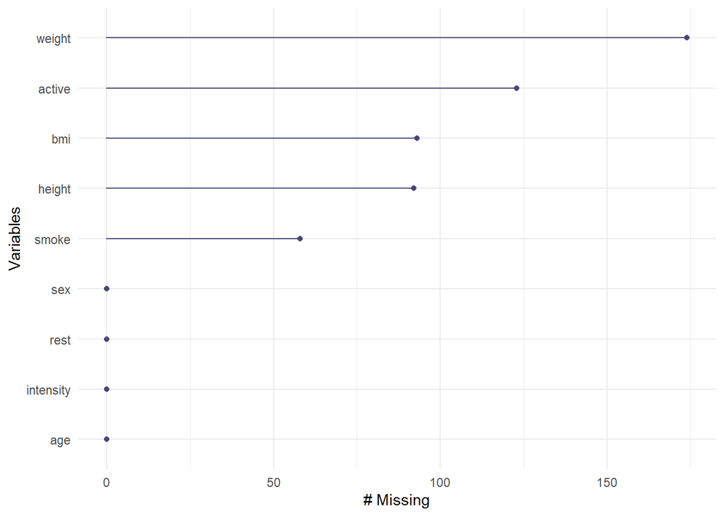

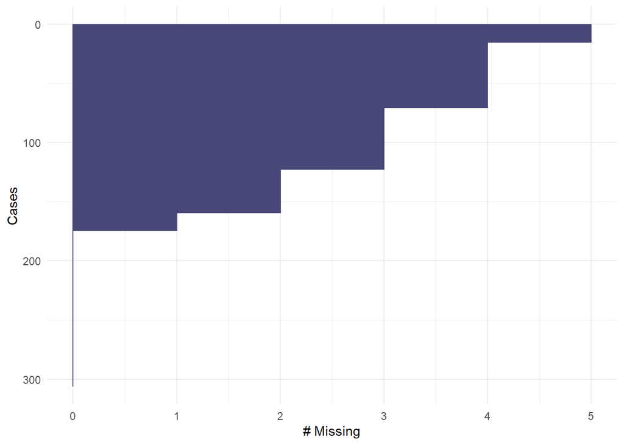

Figure 3.1: pattern of the missingness

## 3.1 Looking for the missingness

weight: $t =$ 0.381, $p =$ 0.704

height: $t =$ 1.271, $p =$ 0.205

bmi: $t =$ 0.336, $p =$ 0.737

active: $t =$ -0.606, $p =$ 0.545

smoke: $x^2 =$ 1.154, $p =$ 0.283

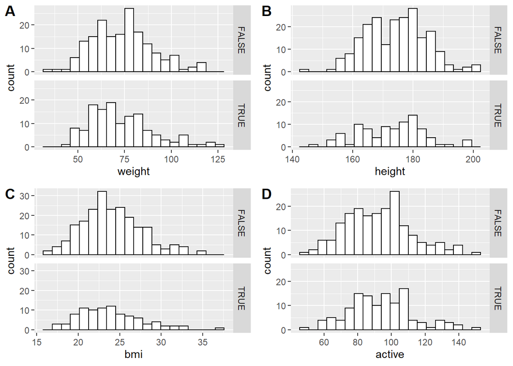

Figure 3.2: comparing the distribution of the observed and true dataset

## 3.2 Missingness of weight

missing weight on sex: $x^2 =$ 0, $p =$ 1

missing weight on smoke: $x^2 =$ 0.036, $p =$ 0.848

missing weight on intensity: $x^2 =$ 2.589, $p =$ 0.274

missing weight on rest: $t =$ -0.482, $p =$ 0.63

missing weight on age: $t =$ -0.59, $p =$ 0.556

missing weight on height: $t =$ -0.639, $p =$ 0.525

missing weight on bmi: $t =$ -0.012, $p =$ 0.99

missing weight on active: $t =$ -1.44, $p =$ 0.156

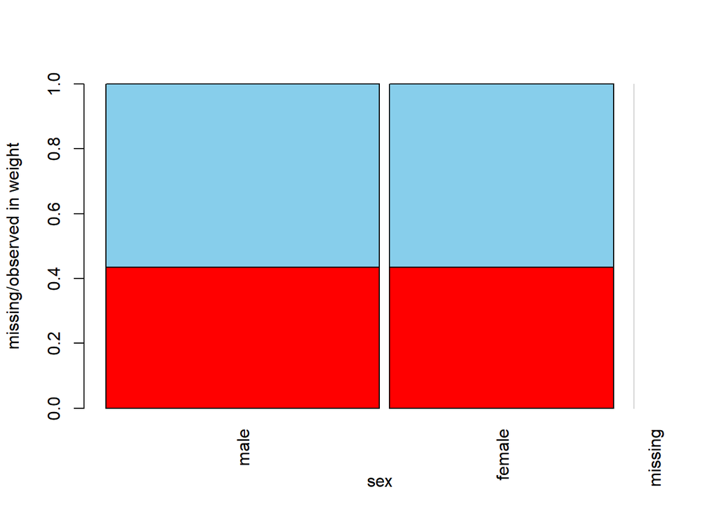

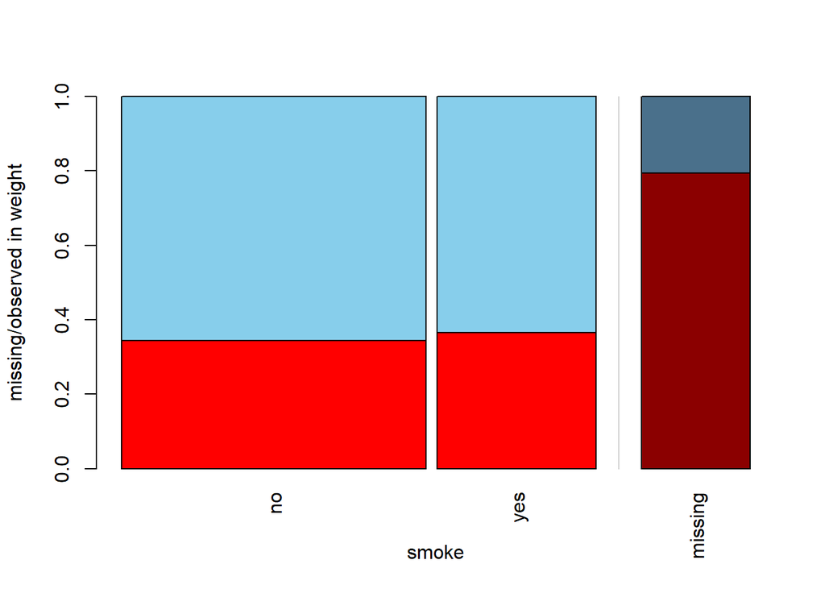

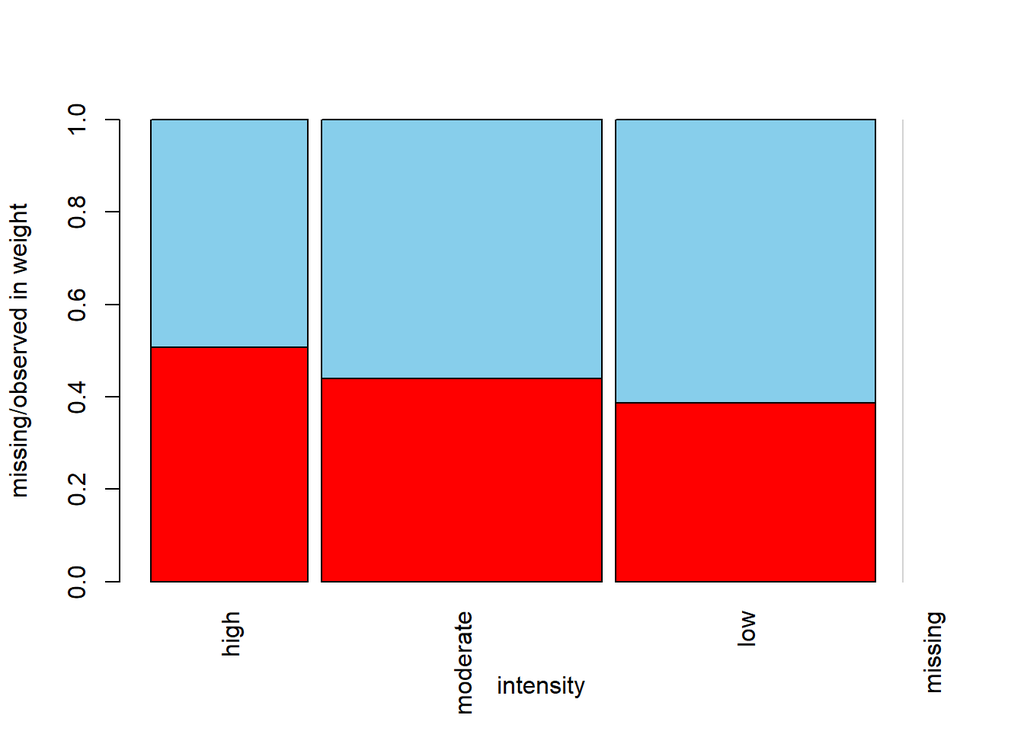

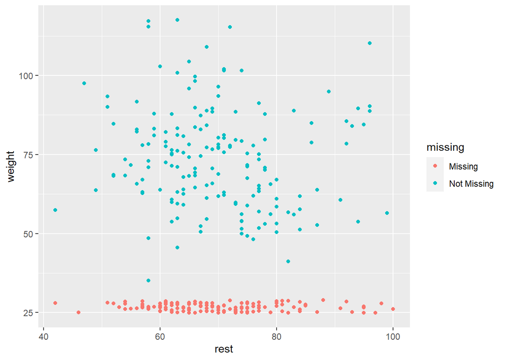

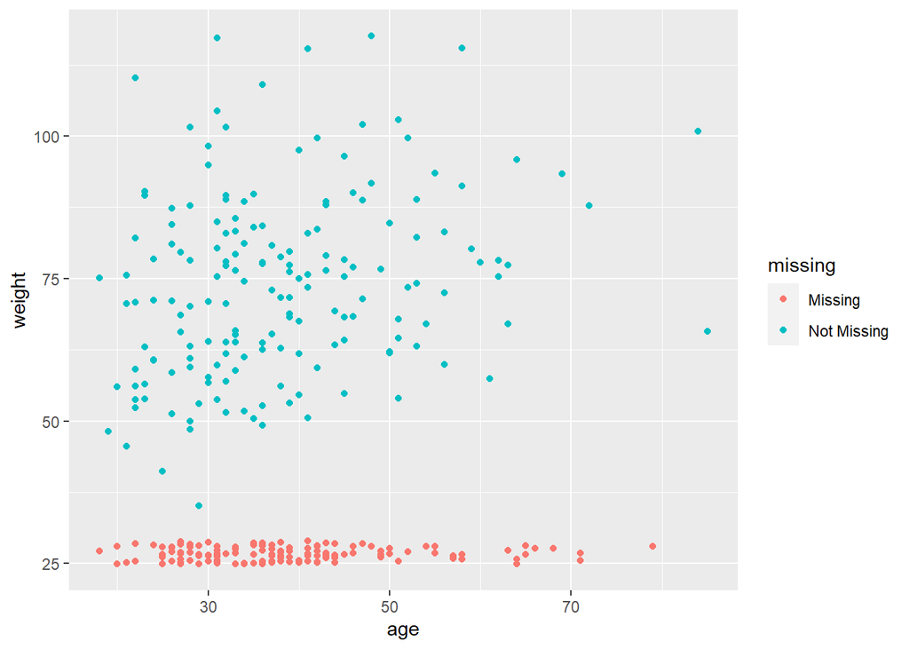

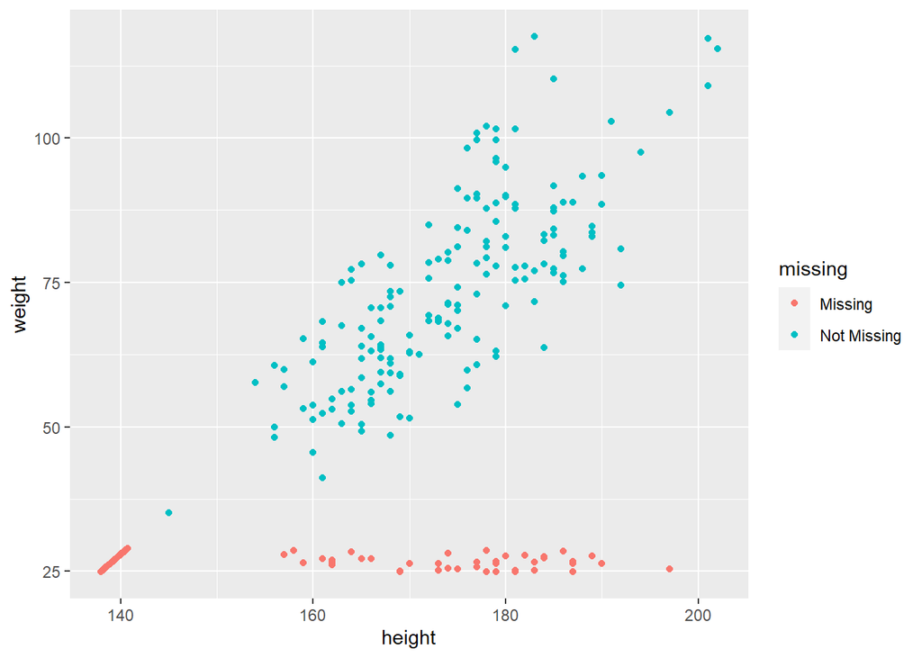

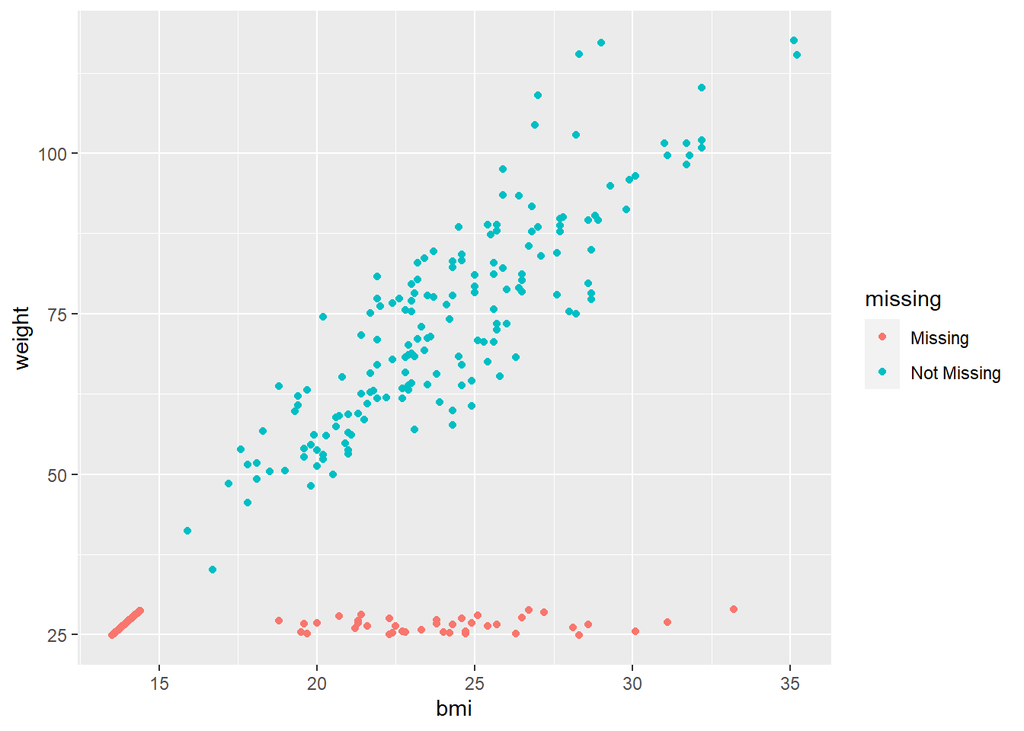

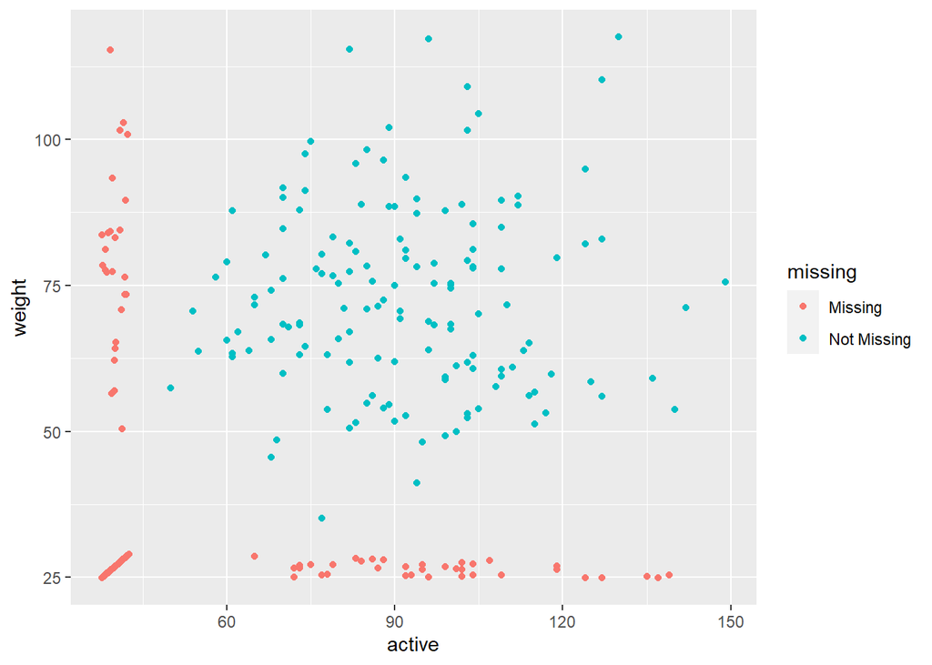

Figure 3.3: Looking whether the missingness of weight is MAR

## 3.3 Missingness of height

missing height on sex: $x^2 =$ 0, $p =$ 1

missing height on smoke: $x^2 =$ 0.111, $p =$ 0.739

missing height on intensity: $x^2 =$ 3.563, $p =$ 0.168

missing height on rest: $t =$ 0.242, $p =$ 0.809

missing height on age: $t =$ 0.32, $p =$ 0.749

missing height on bmi: $t =$ -0.012, $p =$ 0.99

missing height on active: $t =$ -1.535, $p =$ 0.137

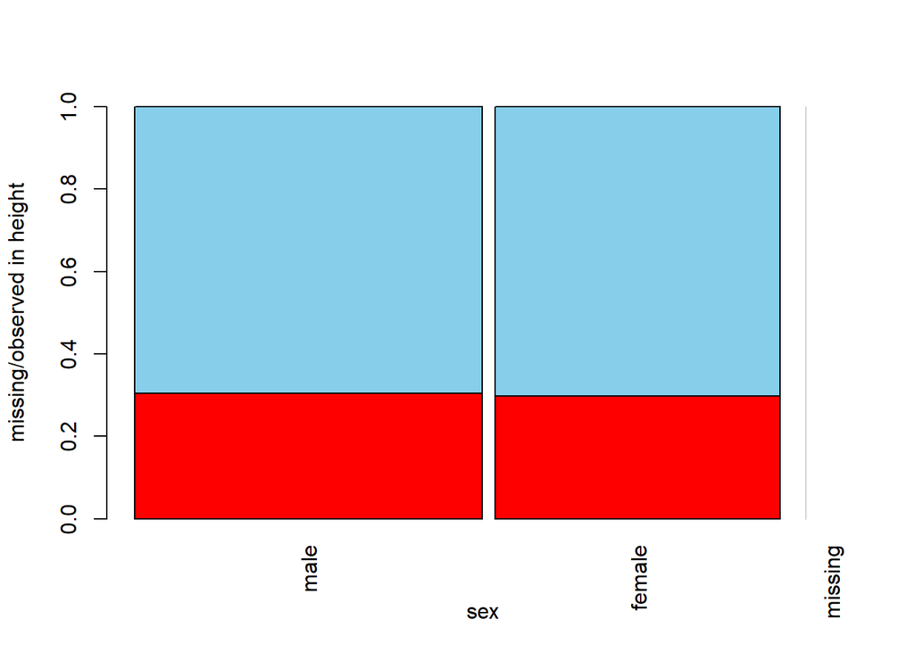

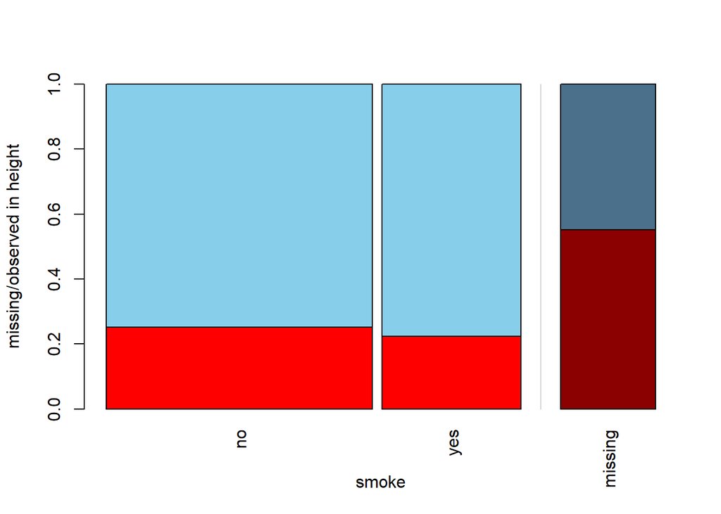

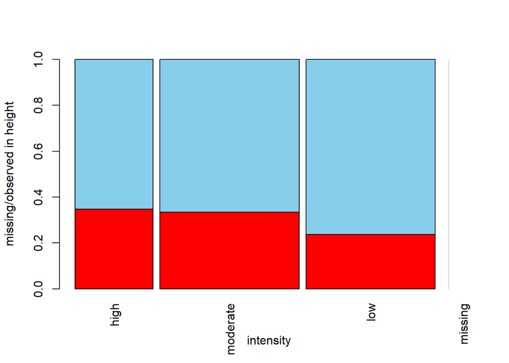

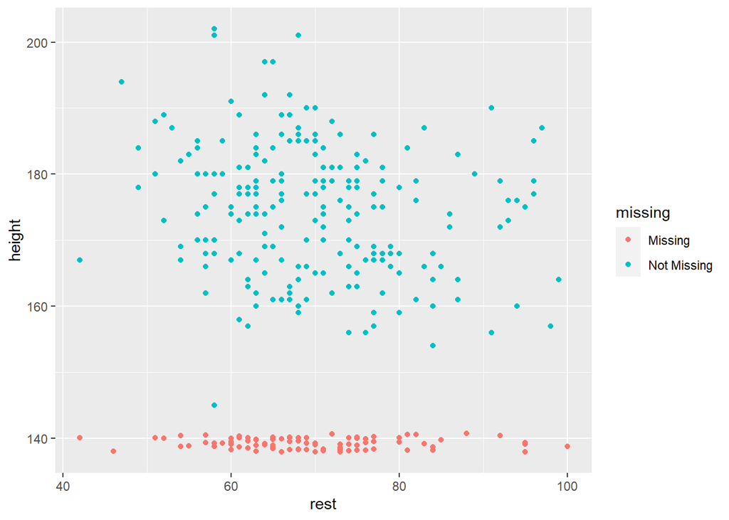

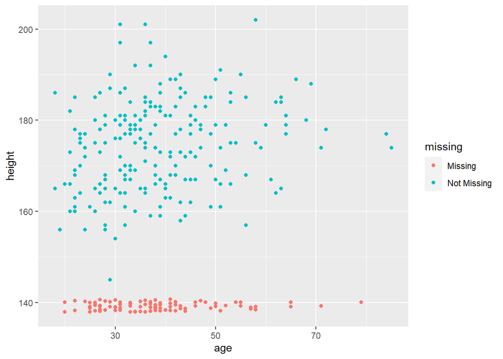

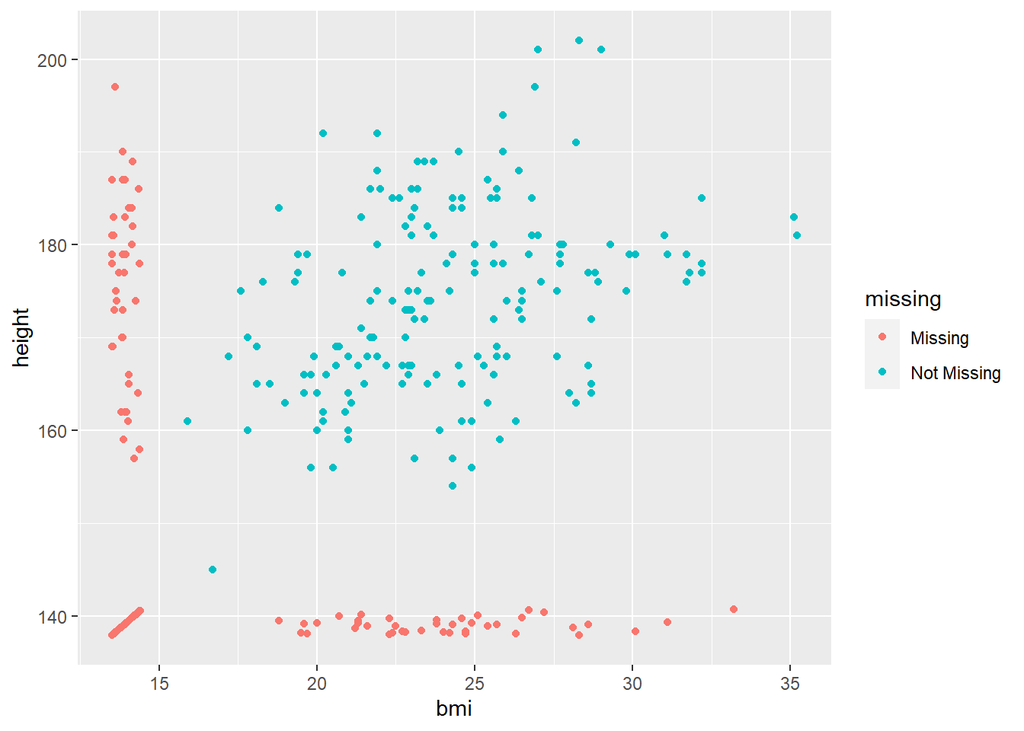

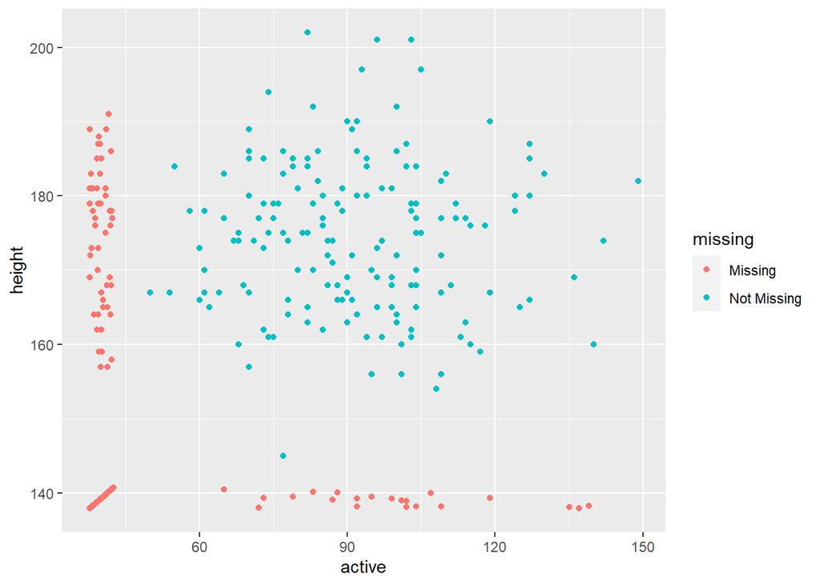

Figure 3.4: Looking whether the missingness of height is MAR

## 3.4 Missingness of Active

missing active on sex: $x^2 =$ 1.957, $p =$ 0.162

missing active on smoke: $x^2 =$ 0.293, $p =$ 0.589

missing active on intensity: $x^2 =$ 2.193, $p =$ 0.334

missing active on rest: $t =$ -1.558, $p =$ 0.12

missing active on age: $t =$ -0.963, $p =$ 0.337

missing active on height: $t =$ -0.232, $p =$ 0.817

missing active on bmi: $t =$ -1.883, $p =$ 0.062

missing active on weight: $t =$ -1.948, $p =$ 0.059

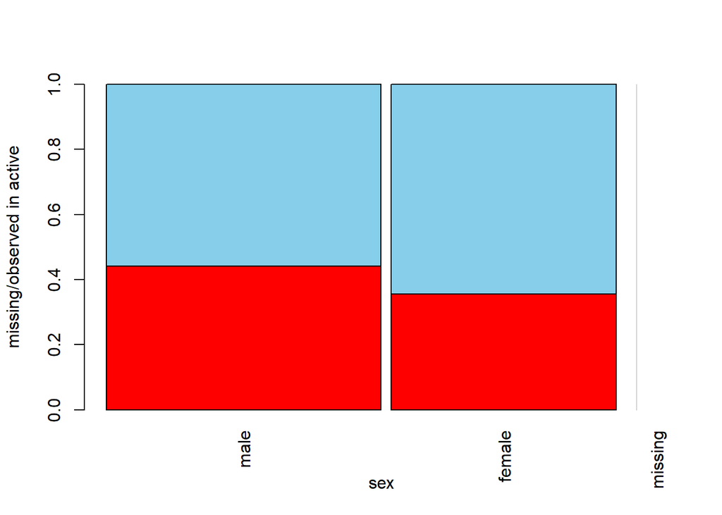

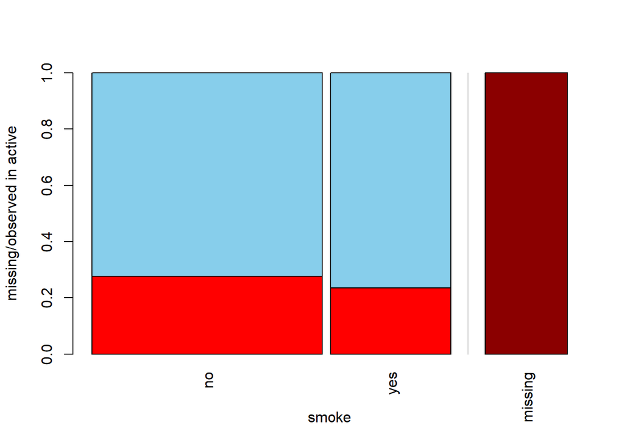

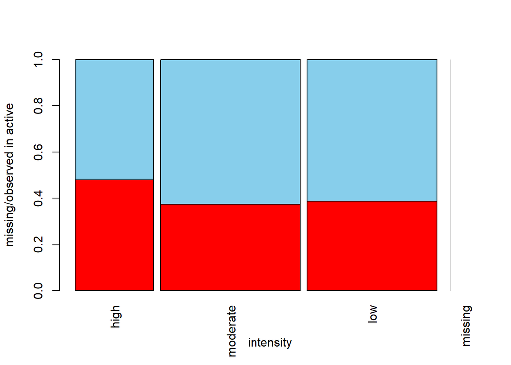

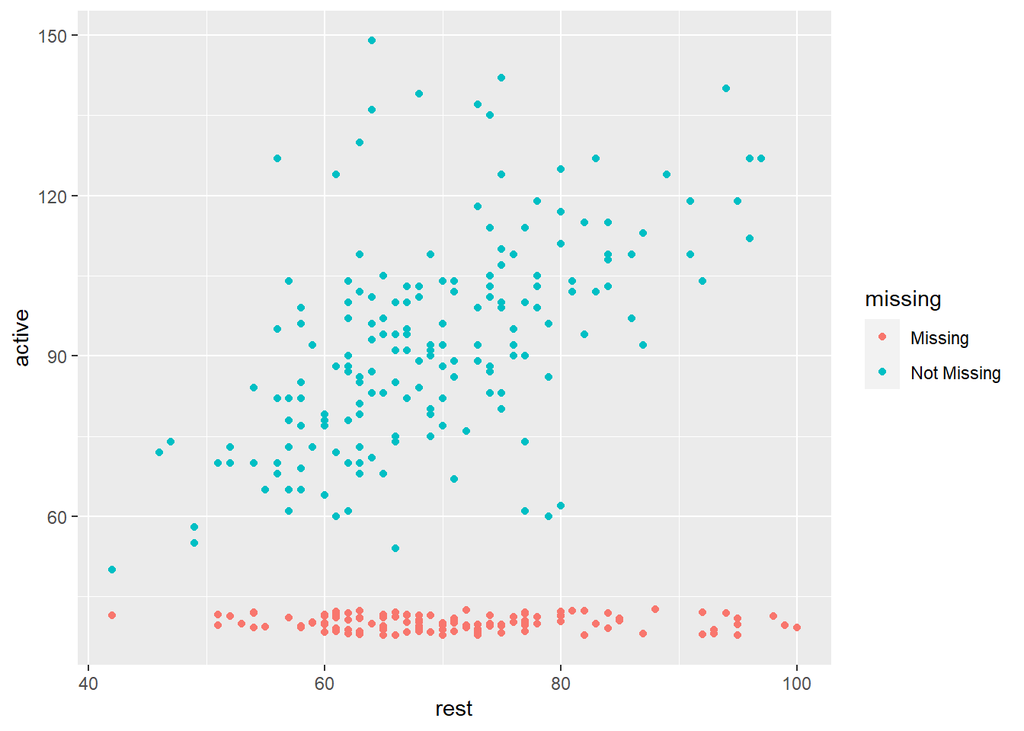

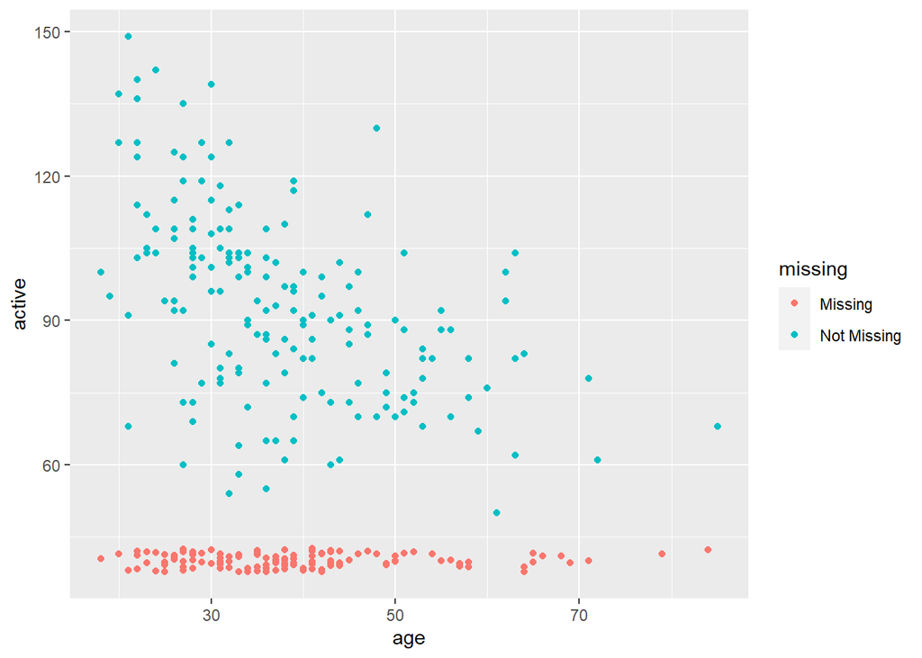

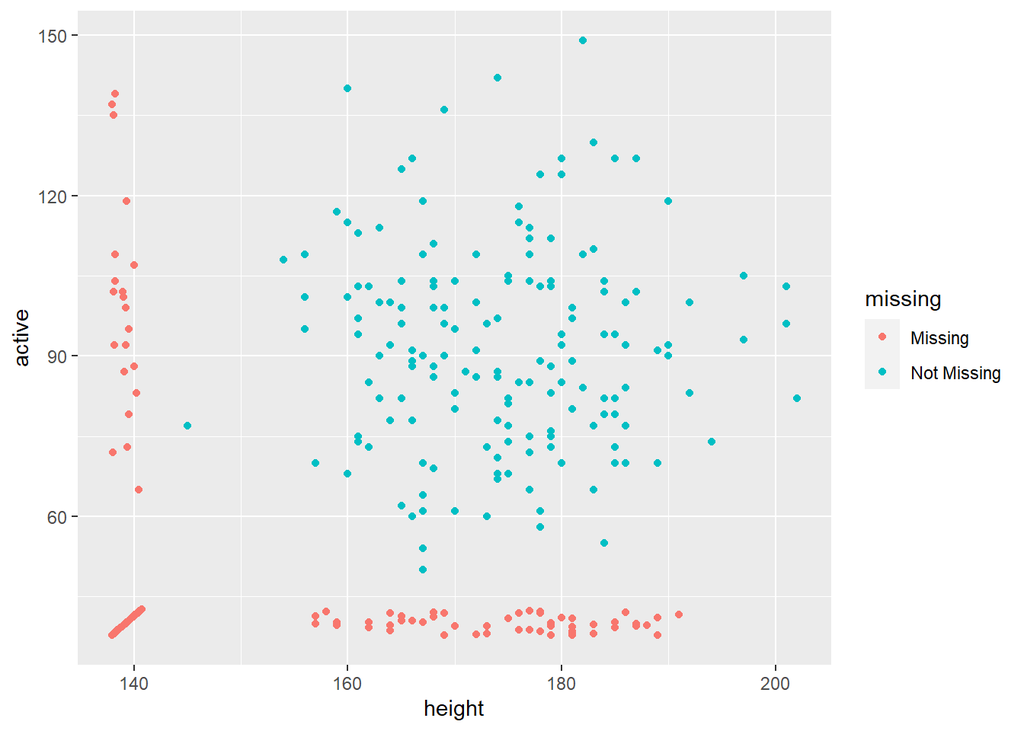

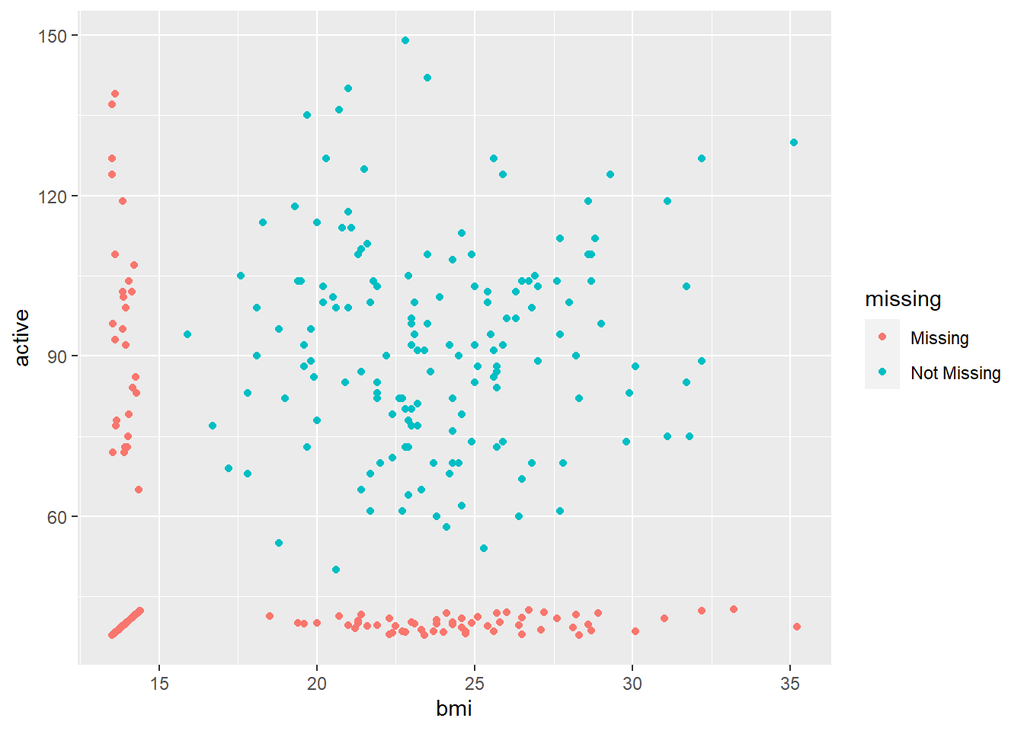

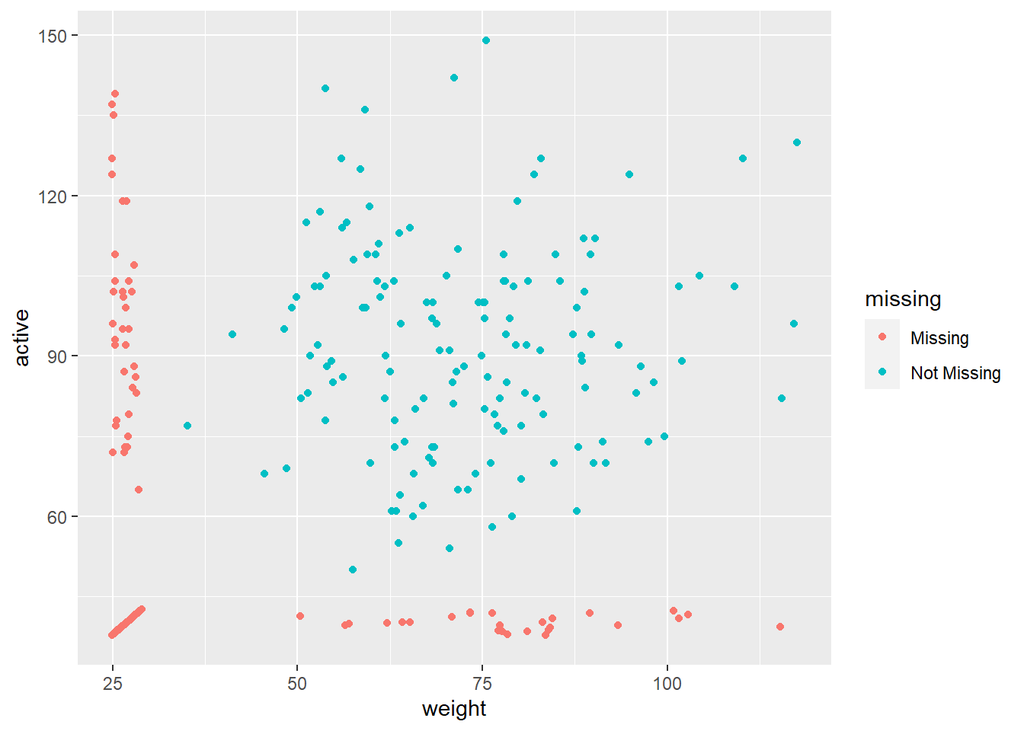

Figure 3.5: Looking whether the missingness of active is MAR

## 3.5 Missingness of Bmi

missing bmi on sex: $x^2 =$ 0.019, $p =$ 0.889

missing bmi on smoke: $x^2 =$ 0, $p =$ 1

missing bmi on intensity: $x^2 =$ 1.476, $p =$ 0.478

missing bmi on rest: $t =$ 0.021, $p =$ 0.983

missing bmi on age: $t =$ -0.368, $p =$ 0.713

missing bmi on height: $t =$ -0.639, $p =$ 0.525

missing bmi on active: $t =$ -0.717, $p =$ 0.478

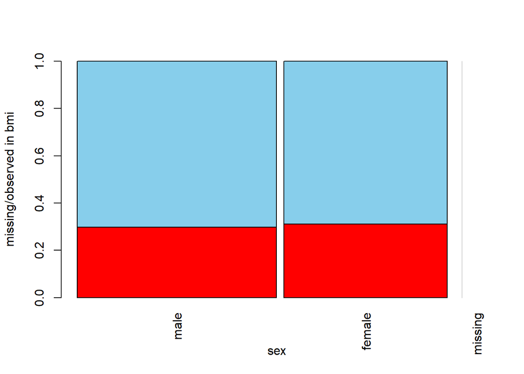

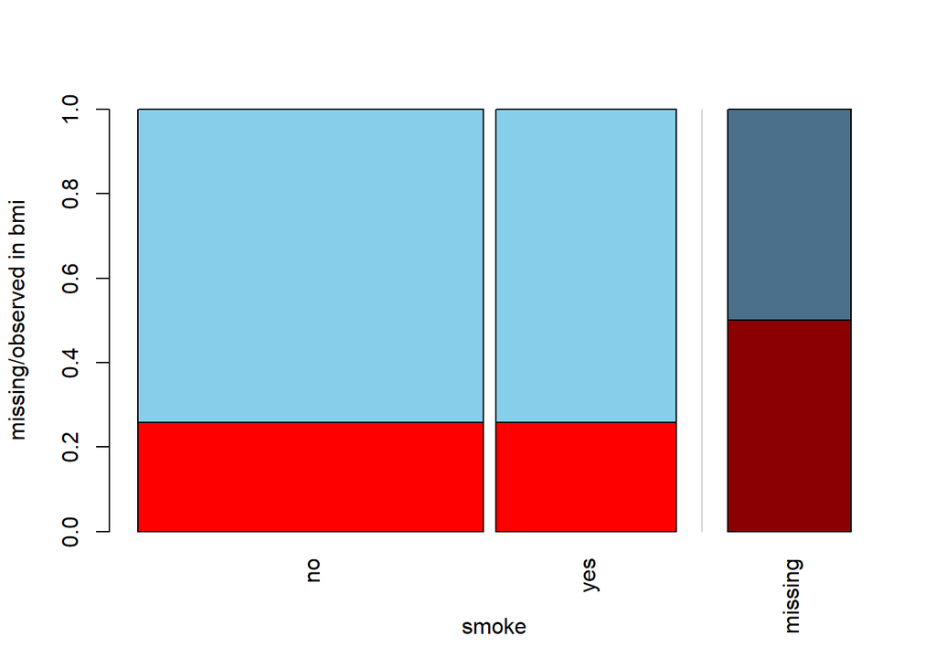

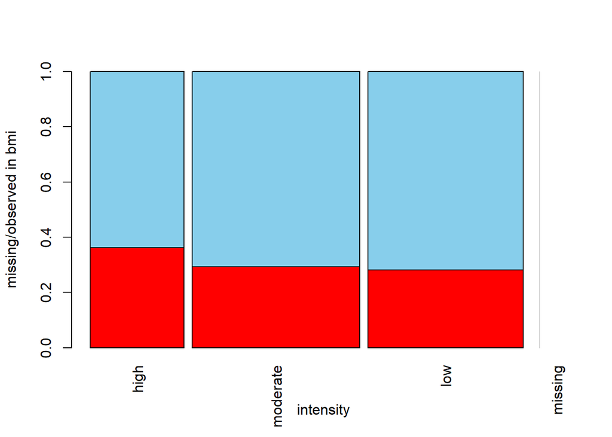

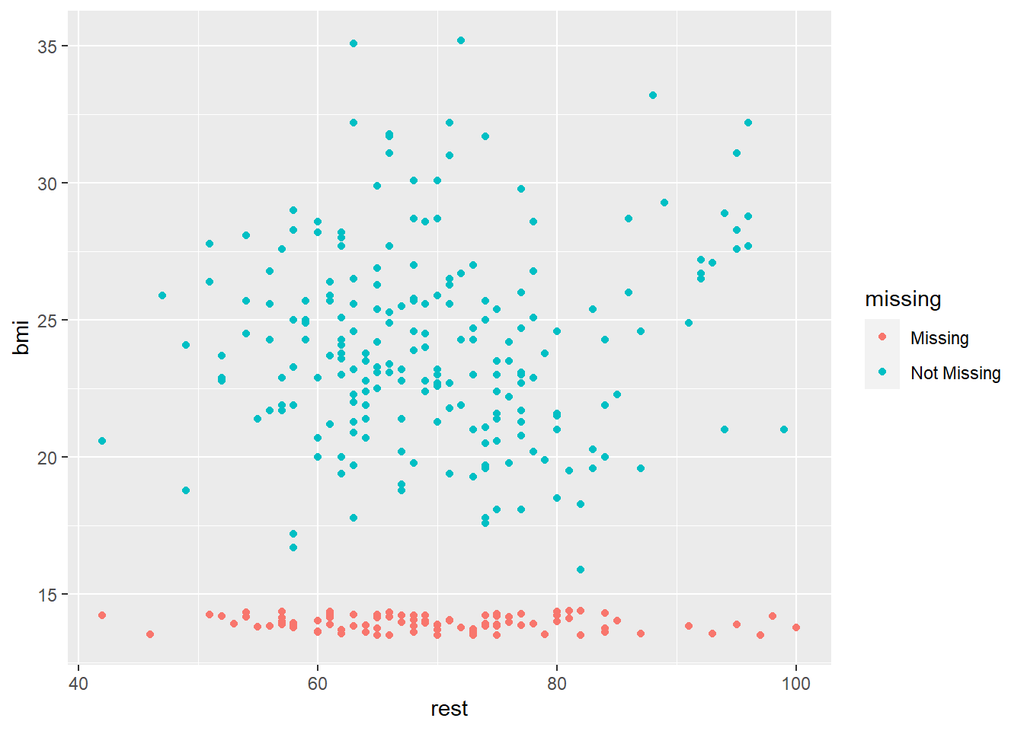

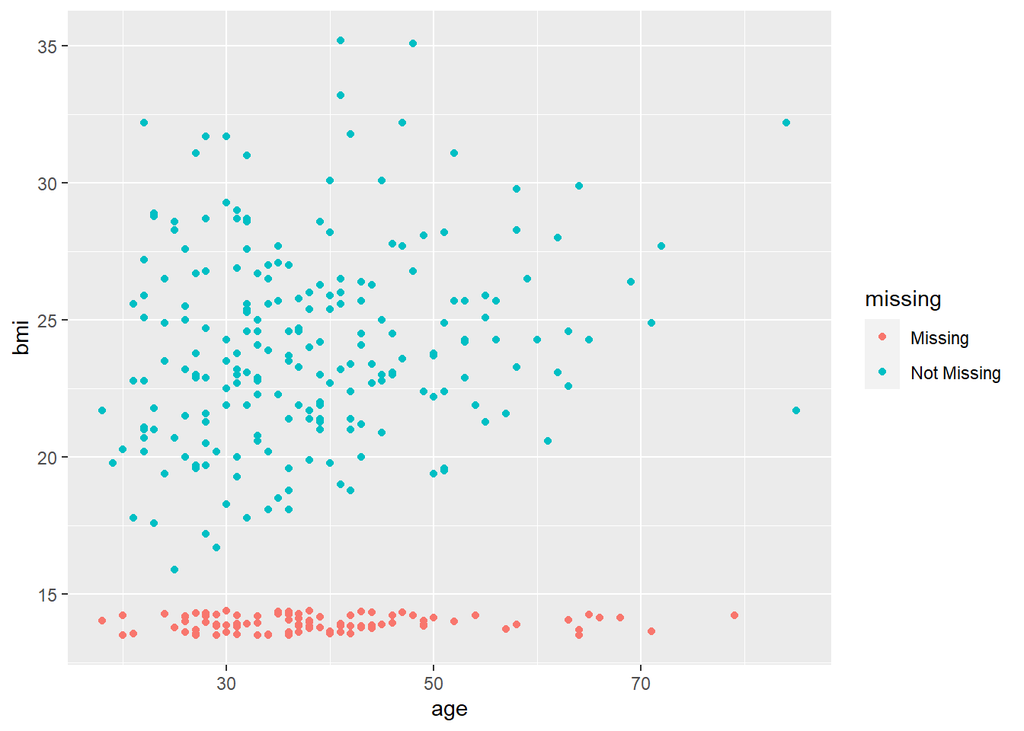

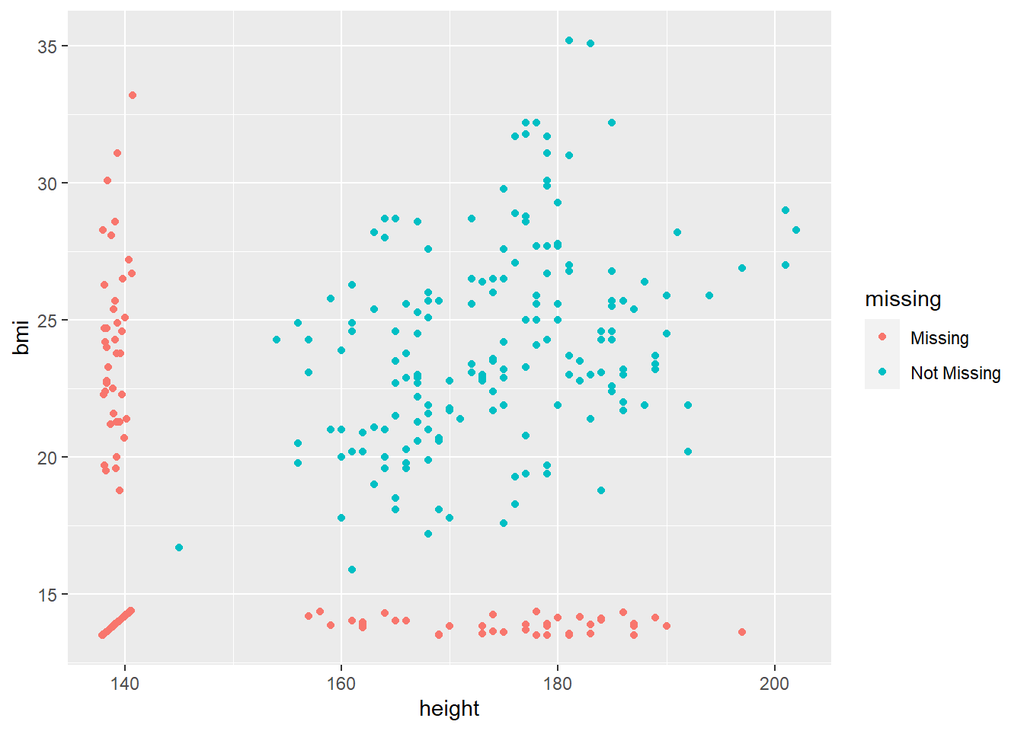

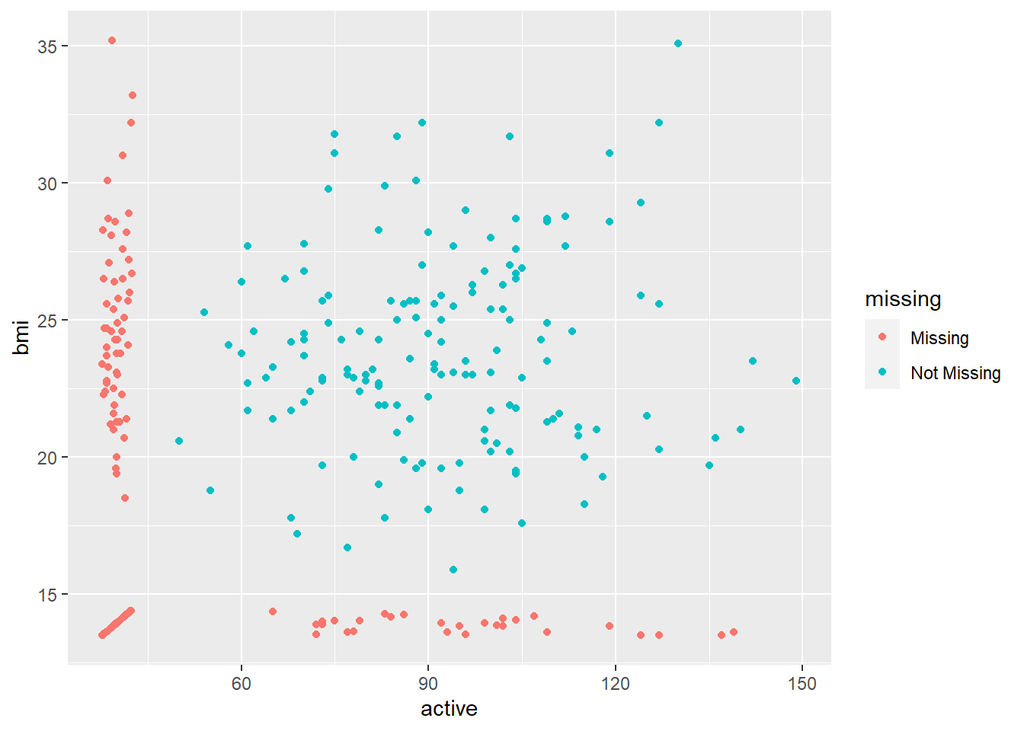

Figure 3.6: Looking whether the missingness of bmi is MAR

## 3.6 Missingness of Smoke

missing smoke on sex: $x^2 =$ 5.037, $p =$ 0.025

missing smoke on intensity: $x^2 =$ 1.722, $p =$ 0.423

missing smoke on rest: $t =$ 0.779, $p =$ 0.438

missing smoke on age: $t =$ -1.271, $p =$ 0.208

missing smoke on height: $t =$ -0.347, $p =$ 0.731

missing smoke on bmi: $t =$ -1.338, $p =$ 0.188

missing smoke on weight: $t =$ -0.785, $p =$ 0.444

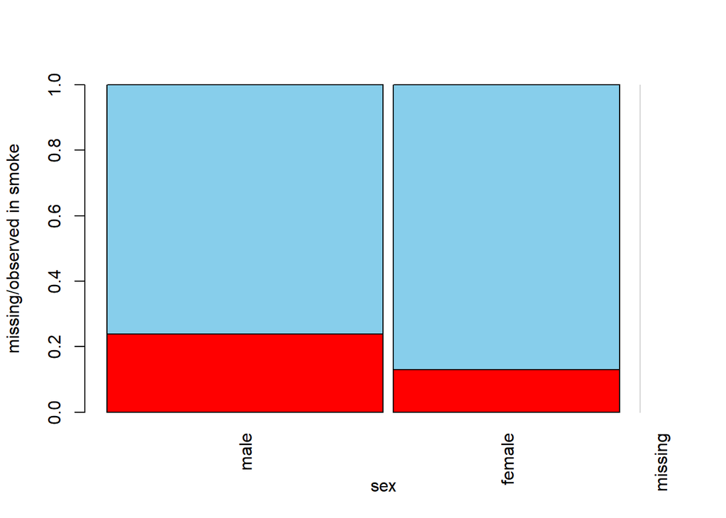

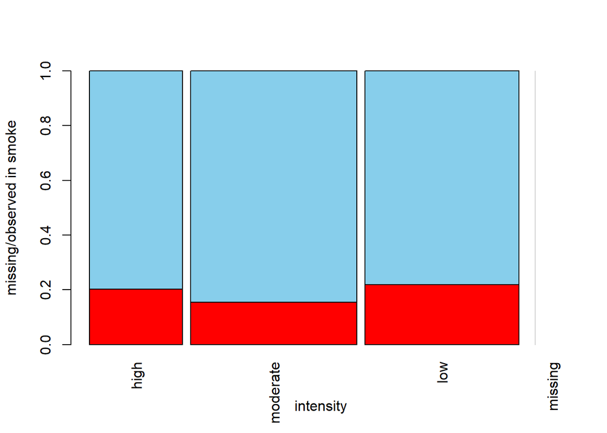

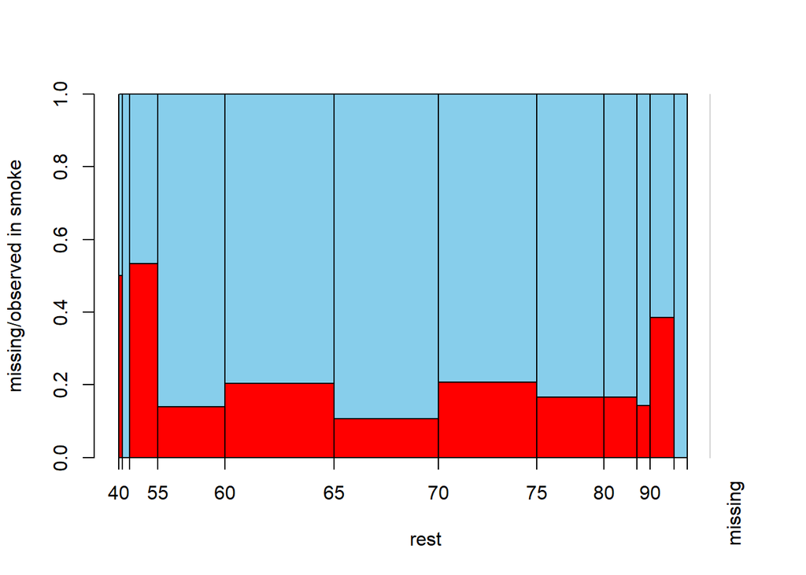

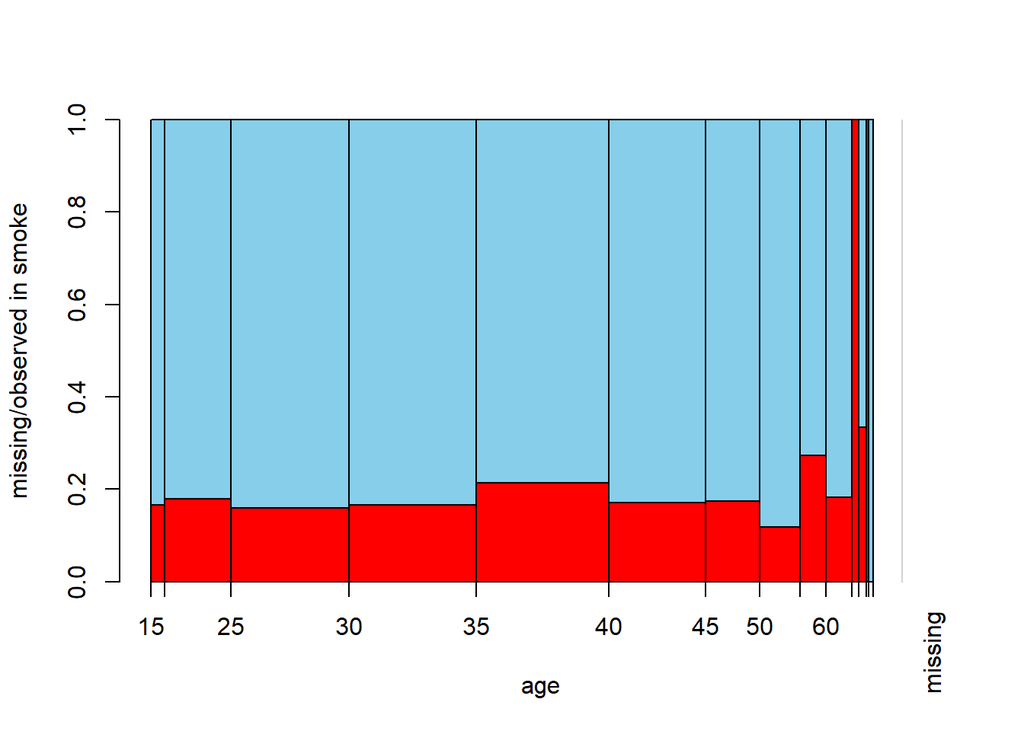

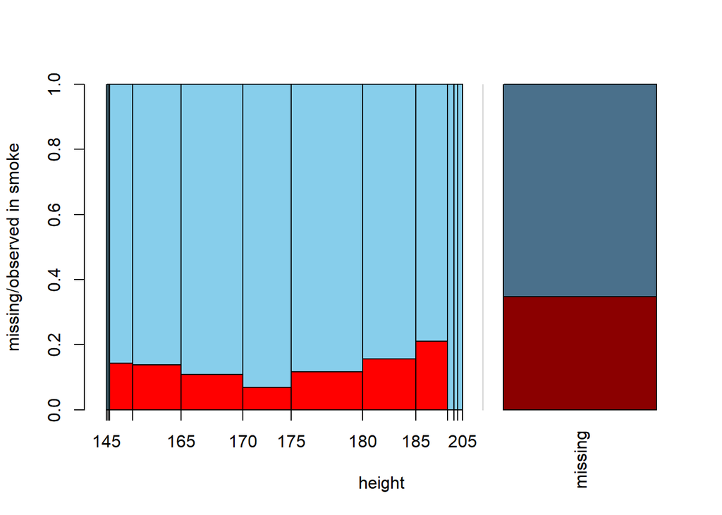

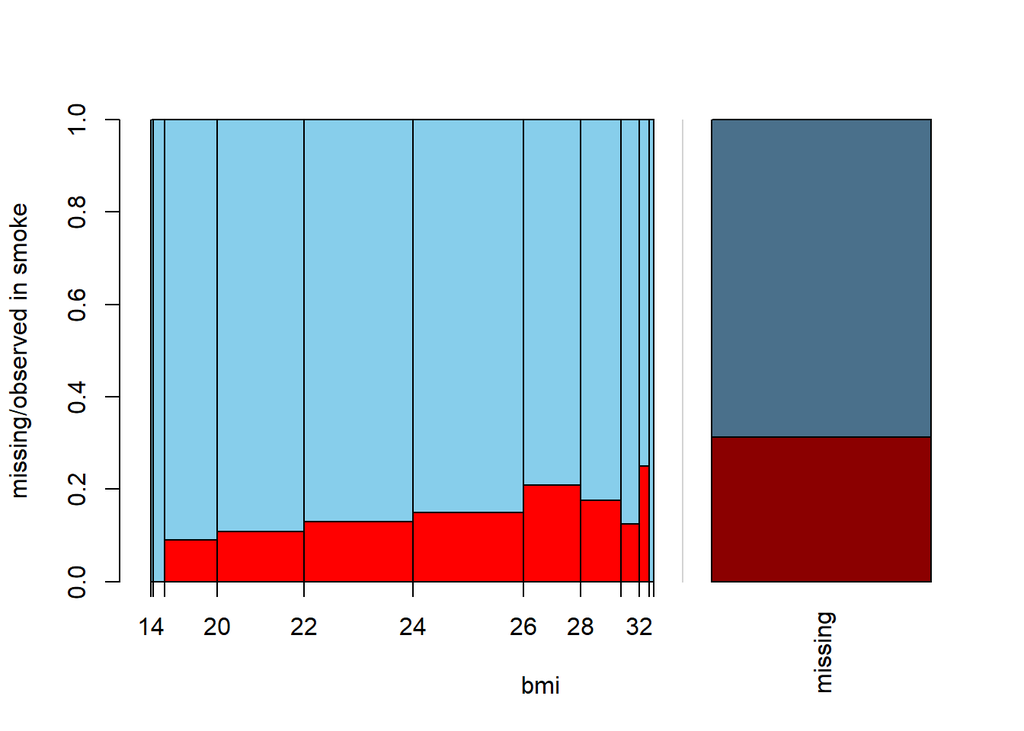

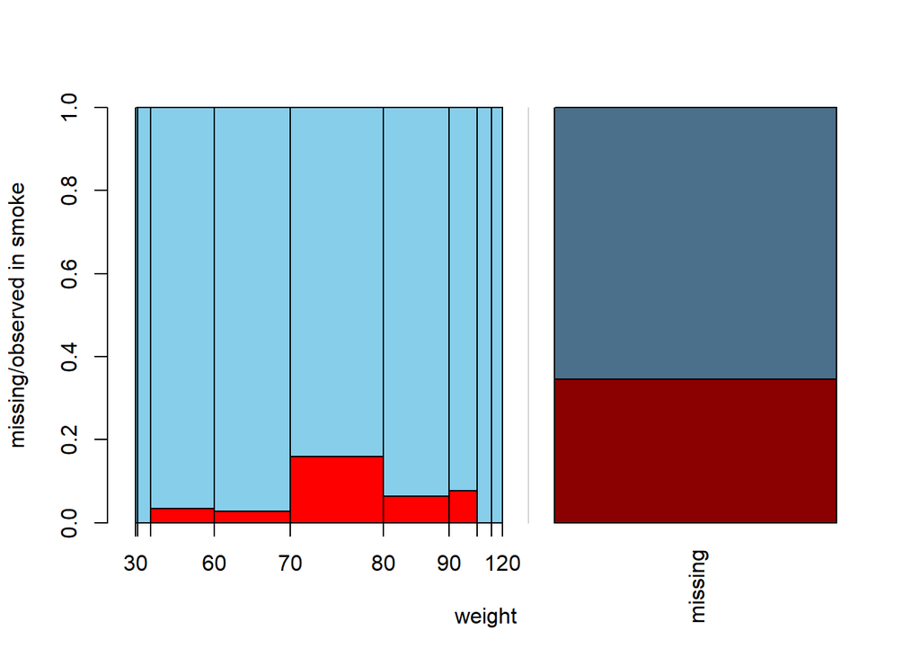

Figure 3.7: Looking whether the missingness of smoking is MAR